# Untitled

LEE EUNJI

2019년 6월 19일

### [날짜별 주문량]

1. 날짜, 요일, 월 변수들을 시각화하기 위한 형태로 정리

```r
setwd("C:\\Users\\EUNJI\\Desktop\\ds_yonsei\\프로젝트\\data\\real")
its_eats <- read.csv("final_0606.csv",header = TRUE)
library(tidyverse)
its_eats_1 <- its_eats
its_eats_1$day.x <- as.character(its_eats_1$day.x)
its_eats_1$day.x <- factor(its_eats_1$day.x,
                         levels=c("월","화","수","목","금","토","일"))

calls <- its_eats_1 %>%
  group_by(type,date) %>%
  dplyr::summarise(total=sum(call))
```

### [날짜별 주문량]

1. 날짜, 요일, 월 변수들을 시각화하기 위한 **형태**로 정리  
   = 날짜형 데이터로 변환

```r
calls$date <- paste(str_sub(calls$date,start=1,end=4),
                    "-",
                    str_sub(calls$date,start=5,end=6),
                    "-",
                    str_sub(calls$date,start=7,end=8),
                    sep="")
calls$date <- as.Date(calls$date)
calls$month <- as.numeric(as.POSIXlt(calls$date)$mon+1)
              # 월 변수 추가
calls$monthf <- factor(calls$month,levels=as.character(1:12),
                       labels = c("Jan","Feb","Mar","Apr",
                                  "May","Jun","Jul","Aug",
                                  "Sep","Oct","Nov","Dec"),
                       ordered = TRUE) # 월 이름 추가
```

### [날짜별 주문량]

1. 날짜, 요일, 월 변수들을 시각화하기 위한 **형태**로 정리  
   = 날짜형 데이터로 변환

```r
calls$weekday <- as.POSIXlt(calls$date)$wday
calls$weekdayf <- factor(calls$weekday, levels= c(0,6,5,4,3,2,1),
                         labels=rev(c("Mon","Tue","Wed","Thu",
                                      "Fri","Sat","Sun")),
                         ordered=TRUE)
calls$yearmonth <- zoo::as.yearmon(calls$date)
calls$yearmonthf <- factor(calls$yearmonth)
calls$week <- as.numeric(format(as.Date(calls$date),
                                "%W"))
```

2.날짜별 주문량 시각화

```r
library(plyr)
```

```r
calls <- ddply(calls,.(yearmonthf),transform,
               monthweek=1+week-min(week))
p1 <- ggplot(calls,aes(monthweek,weekdayf,fill=total)) +
  geom_tile(colour="white") + facet_grid(type~monthf) +
  scale_fill_gradient(low="yellow",high="red")
```

### [날짜별 주문량]

2.날짜별 주문량 시각화

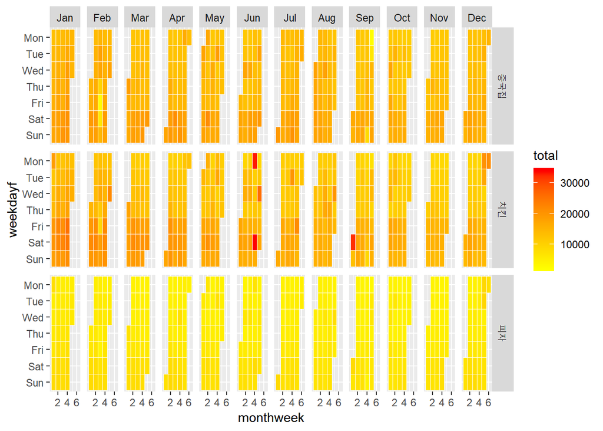

```r
p1
```

### [날짜별 주문량]

3.**그래프 꾸미기…?**

```r
myTheme <- theme(
  panel.background = element_rect(fill = "white"),
  panel.grid.major = element_line(colour = "lightgrey"),
  panel.grid.minor = element_line(colour = "lightgrey"),
  strip.background = element_rect(fill = "black"),
  strip.text = element_text(color = "white"),
  axis.text = element_text(color = "black")
)
calls_cn <- calls %>% filter(type=="중국집")
calls_ck <- calls %>% filter(type=="치킨")
calls_pz <- calls %>% filter(type=="피자")
```

### [날짜별 주문량]

3.**그래프 꾸미기…?**

```r
p1_cn <- ggplot(calls_cn,aes(monthweek,
                             weekdayf,fill=total)) +
  geom_tile(colour="white") + facet_grid(.~monthf) +
  scale_fill_gradient(low="white",high="#EA4335") +
  labs(title = "2018년 중국집 주문 량") +
  ylab("") + xlab("") + myTheme
p1_ck <- ggplot(calls_ck,aes(monthweek,
                             weekdayf,fill=total)) +
  geom_tile(colour="white") + facet_grid(~monthf) +
  scale_fill_gradient(low="white",high="#4285F4") +
  labs(title = "2018년 치킨 주문 량") +
  ylab("") + xlab("") + myTheme
```

### [날짜별 주문량]

3.**그래프 꾸미기…?**

```r
p1_pz <- ggplot(calls_pz,aes(monthweek,weekdayf,
                             fill=total)) +
  geom_tile(colour="white") + facet_grid(~monthf) +
  scale_fill_gradient(low="white",high="#FBBC05")+
  labs(title = "2018년 피자 주문 량") +
  ylab("") + xlab("") + myTheme
library(gridExtra)
```

### [날짜별 주문량]

3.**그래프 꾸미기…?**

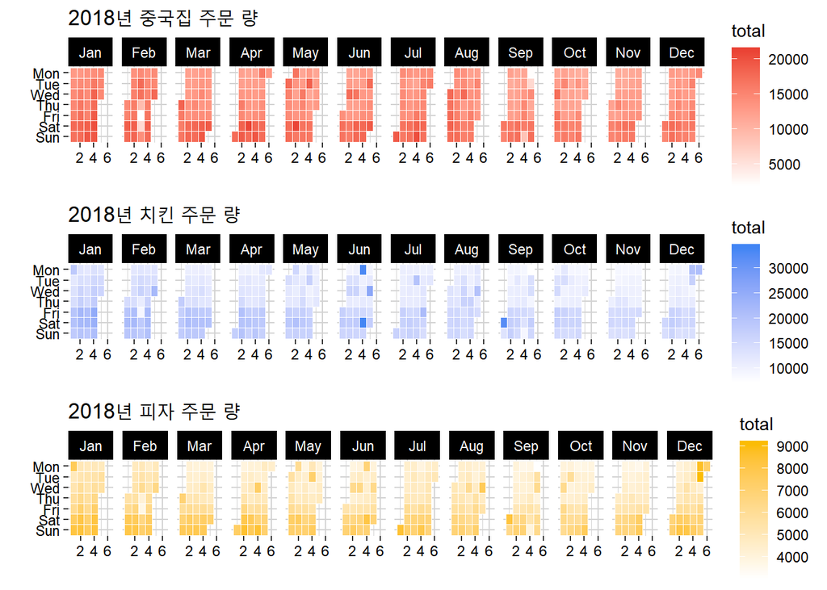

```r
grid.arrange(p1_cn,p1_ck,p1_pz,ncol=1)
```

- 중국집, 치킨, 피자 모두 주말에 주문량이 많음
- 12월 24일, 25일의 경우 피자 주문량 증가

### [지역별, 요일별 주문량]

1. 지역, 요일별 데이터 추출

```r
days <- its_eats_1 %>%
        group_by(type, day.x,region) %>%
        dplyr::summarise(total=sum(call)) %>%
        arrange(desc(total))
days$day.x <- factor(days$day.x,
                     levels = c("월","화","수","목","금","토","일"))
```

### [지역별, 요일별 주문량]

2.데이터 시각화

```r
p2 <- ggplot(data = days,
             aes(x = day.x,
                y = total,color=type ,group = type)) +
  geom_line(size=1) +
  facet_wrap(~ region) +
  theme_bw() +
  theme(panel.grid.minor.x = element_blank(),
        panel.grid.major.y = element_blank(),
        panel.grid.minor.y = element_blank(),
        strip.background = element_rect(fill = "steelblue"),
        strip.text = element_text(color = "white")
  ) +
  scale_color_manual(values=c("#EA4335", "#4285F4", "#FBBC05"))
```

### [지역별, 요일별 주문량]

2.데이터 시각화

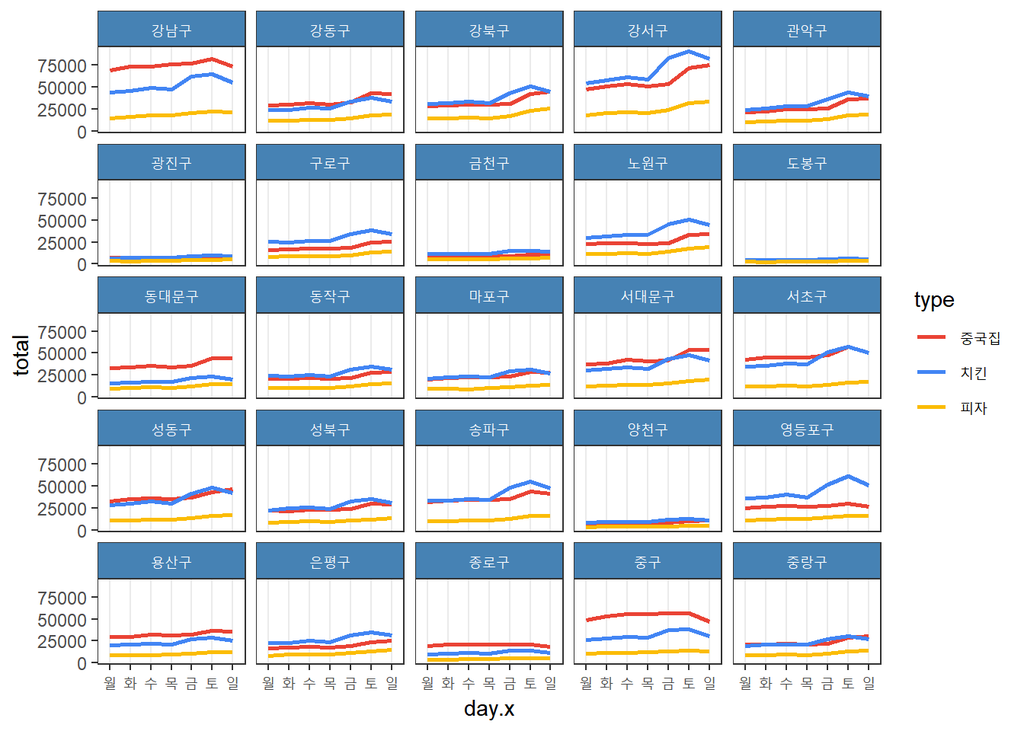

```r
p2
```

- 강남구, 강서구, 중구의 주문량 많음
- 광진구, 금천구, 도봉구, 양천구의 주문량 적음
- 피자는 모든 구에서 주문량이 가장 적음

### [성별에 따른 주문량]

1. 성별과 주문량 데이터 추출

```r
genders <- its_eats_1 %>% group_by(gender,type) %>%
  dplyr::summarise(total=sum(call)) %>%
  arrange(gender,desc(type))
genders  <- ddply(genders, "gender",transform,
                  label_ypos=cumsum(total))
genders  <- ddply(genders, "gender",transform,
                  pct=round(total/sum(total),2)*100)
```

### [성별에 따른 주문량]

2.데이터 시각화

```r
p3 <-  ggplot(genders, aes(x=gender,y=total,fill=type))+
  geom_bar(stat="identity") + theme_bw() +
  scale_fill_manual(values=c("#EA4335", "#4285F4", "#FBBC05")) +
  geom_text(aes(y=label_ypos, label=paste(pct,"%")),
            vjust=1.6,color="white", size=5) +
  geom_text(aes(y=label_ypos-400000, label=paste("(",total,"건)")),
            vjust=1.6,color="white", size=3)
```

### [성별에 따른 주문량]

2.데이터 시각화

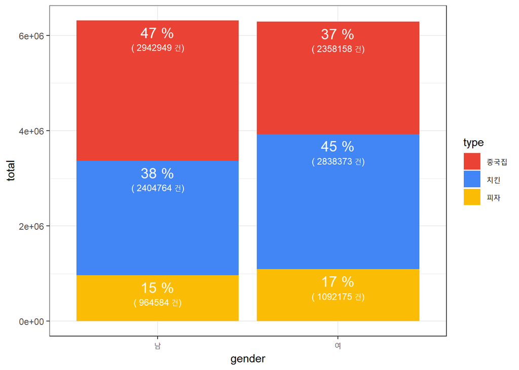

```r
p3
```

- 남 : 중국집 > 치킨 > 피자
- 여 : 치킨 > 중국집 > 피자

### [연령에 따른 주문량]

1. 연령별 주문량 추출

```r
ages <- its_eats_1 %>% group_by(age,type) %>%
  dplyr::summarise(total=sum(call)) %>%
  arrange(age,desc(type))
ages <- ddply(ages, "age",transform,label_ypos=cumsum(total))
ages <- ddply(ages, "age",transform,
              pct=round(total/sum(total),2)*100)
ages <- ddply(ages, "age",transform,label_ypos2 = sum(total))
```

### [연령에 따른 주문량]

2.데이터 시각화

```r
p4 <- ggplot(ages, aes(x=age,y=total,fill=type)) +
            geom_bar(stat="identity") + theme_bw() +
  scale_fill_manual(values=c("#EA4335", "#4285F4", "#FBBC05")) +
  geom_text(aes(y=label_ypos+50000, label=paste(pct,"%")),
            vjust=1.6,color="white", size=5) +
  geom_text(aes(y=label_ypos2+300000, label=paste(label_ypos2,"건")),
            vjust=1.6,color="black", size=4)
```

### [연령에 따른 주문량]

2.데이터 시각화

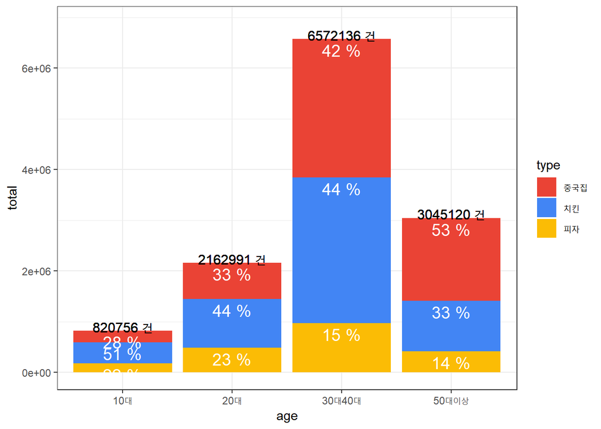

```r
p4
```

- 30대40대 > 50대이상 > 20대 > 10대
- 10대의 치킨 주문은 10대 전체 주문량의 반 이상
- 50대 이상을 제외한 모든 연령대에서 치킨 주문량이 제일 많음
- 30대40대는 중국집, 치킨 주문량 비슷
- 50대 이상은 중국집 주문량이 제일 많음

### [강수량에 따른 주문량]

- 비가 안온 날을 포함하면 mean_ganasu가 0인 쪽에 몰림  
  -> 비가 온 날 위주로 시각화
1. 강수량, 주문량 데이터 추출 (비가 온 날)

```r
gangsus <- its_eats_1 %>%
  group_by(date) %>%
  dplyr::summarise(mean_gangsu = mean(gangsu))
data_p5 <- its_eats_1 %>%
  filter(gangsu>0) %>%
  group_by(date,type,day.x) %>%
  dplyr::summarise(total=sum(call))
data_p5 <- left_join(data_p5,gangsus,by="date")
```

### [강수량에 따른 주문량]

2.데이터 시각화

```r
p5 <- data_p5 %>%
  ggplot(aes(x=mean_gangsu,y=total,color=type)) +
  geom_point(alpha=0.5) +
  facet_wrap(~day.x,scales = "free") +
  scale_color_manual(values=c("#EA4335", "#4285F4", "#FBBC05")) +
  theme_bw() +
  stat_smooth(method="gam",se=FALSE)+
  theme(strip.background = element_rect(fill = "black"),
        strip.text = element_text(color = "white"))
```

### [강수량에 따른 주문량]

2.데이터 시각화

[figure not shown]

### [기온에 따른 주문량]

1. 기온, 주문량 추출

```r
temperatures <- its_eats_1 %>%
  group_by(date,type,region) %>%
  dplyr::summarise(total=sum(call),temperature = mean(temperature))
```

### [기온에 따른 주문량]

2.데이터 시각화

```r
p6 <-  ggplot(temperatures, aes(x=temperature,y=total,color=type)) +
  geom_point(alpha=0.6,size=0.6) +
  facet_wrap(~region,scales = "free") +
  scale_color_manual(values=c("#EA4335", "#4285F4", "#FBBC05")) +
  theme_bw() +
  stat_smooth(method="loess",se=FALSE)+
  theme(strip.background = element_rect(fill = "black"),
        strip.text = element_text(color = "white"))
```

2.데이터 시각화

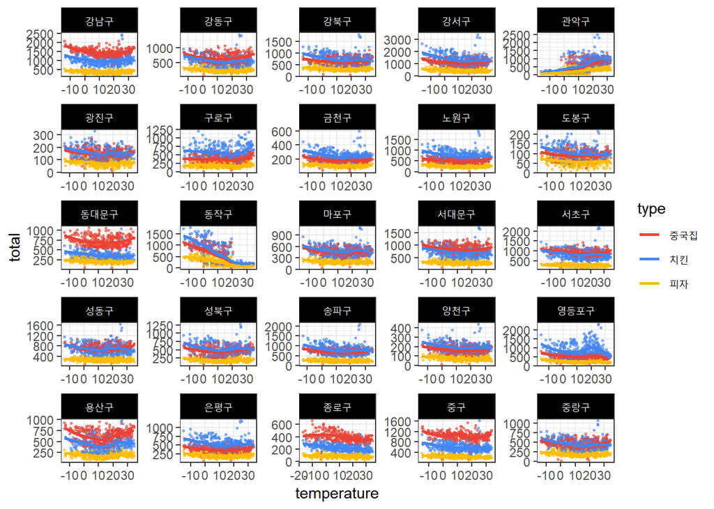